# Lecture 10: Demand Forecasting with Prophet

How Much Demand Should We Plan For?

## Every model serves a marketing decision

Win customers

CMO: “Which channels and touchpoints are actually bringing customers in?”

- L01A/B testingDid it work?
- L03Marketing mix modelingHow much?
- L06Multi-touch attributionHow much?

Set the offer

Head of pricing: “What should we charge, and which features matter?”

- L02Price elasticityHow much?
- L09Conjoint analysisWhat do they want?

The marketing decisionStart from what the business is asking

Keep customers

Head of retention: “Who is leaving, when, and who should get the save offer?”

- L04Survival analysisWhat next?
- L05Markov chainsWhat next?
- L07Uplift modelingDid it work?

Value customers

CFO: “What is a customer worth to us?”

- L08Customer lifetime valueWhat next?

Plan ahead

Operations: “What will next quarter look like?”

- L10Demand forecasting · todayWhat next?

**Question type:**Did it work? causal effectHow much? how much X moves YWhat do they want? preferencesWhat next? prediction

## Motivating Problem

**Tip**

**Setting:** A firm seeks to decompose a time series and generate probabilistic forecasts. How many units should you order? How much budget should marketing plan for? What staffing level does customer support need?

**Learning Objectives**

- Decompose a time series into trend, seasonality, and holiday components
- Fit Prophet and interpret MAPE on a holdout period
- Compute forecasts using seasonal multipliers by hand
- Explain why prediction intervals widen with horizon
- Add changepoints and external regressors to handle structural breaks

## Prophet Decomposition

You need this

$$y(t) = g(t) + s(t) + h(t) + \varepsilon_t$$

| Component | Meaning | Modeled as |
| --- | --- | --- |
| $g(t)$ | Trend | Piecewise linear with changepoints |
| $s(t)$ | Seasonality | Fourier series |
| $h(t)$ | Holidays | Regression on indicator variables |
| $\varepsilon_t$ | Noise | Normally distributed residual |

**Tip**

All components are fitted **jointly, in one fit**, and added together **in the units of $y$** — `s(t) = +$180k` means “$180k above trend this week”. This makes the model **interpretable**.

**Warning**

**Additive components, chained multipliers.** A “+35% lift” is not a component — it is a *ratio to a stated base*. When one lift is quoted **on top of** another, the second one’s base is the first one’s result, so the multipliers **multiply**. `seasonality_mode='multiplicative'` would make the decomposition itself a product; the default is `'additive'` and this course never changes it.

## The Components, Drawn

One simulated online retailer, weekly revenue in $k, 208 weeks; trained on weeks 1–182.

**Trend:** $200k growing $0.6k a week, slowing to $0.25k from week 121.

**Holidays:** three dated weeks, each fitted as a one-off lift.

**Yearly:** peaks in December, lowest in summer.

Every panel is in the units of $y$: in the week of December 23 the yearly component adds about $49k to the trend.

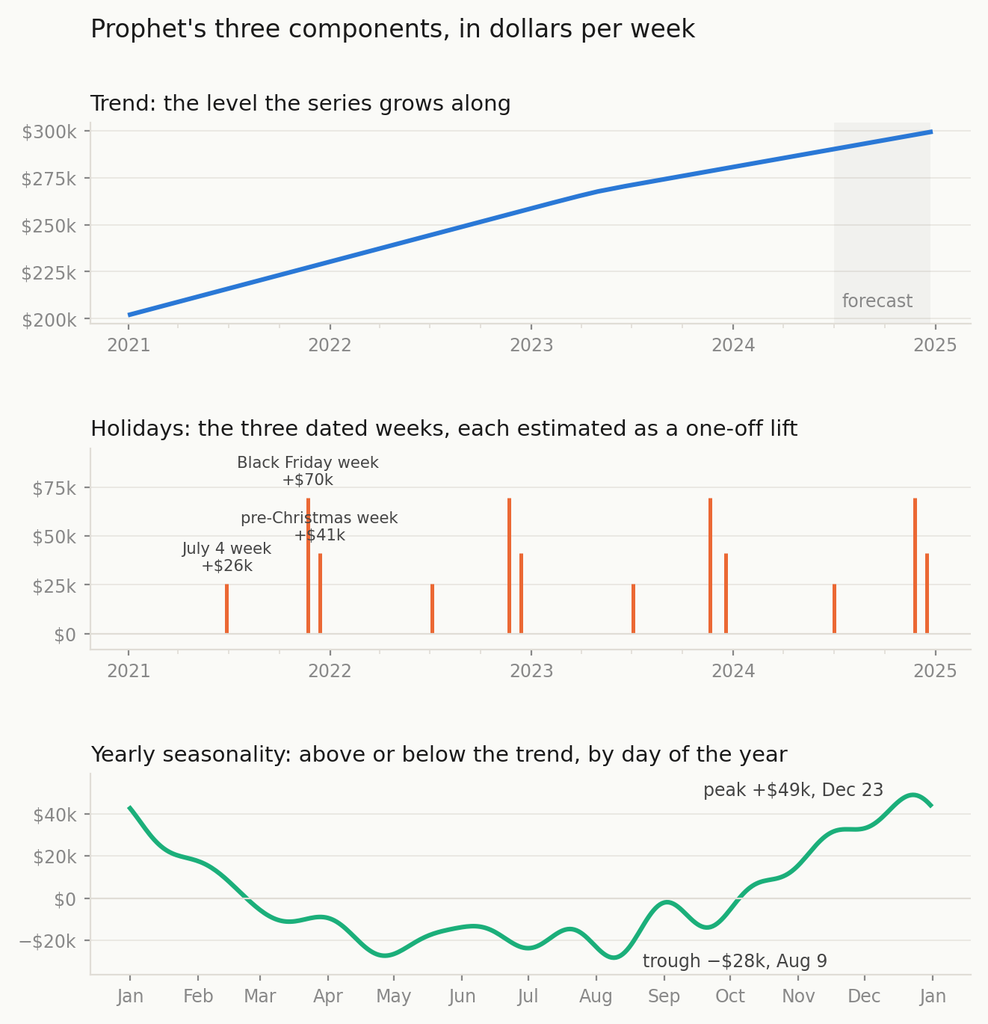

The series and the true values: Notes, Section 1.3.

## Read the Peak off the Data

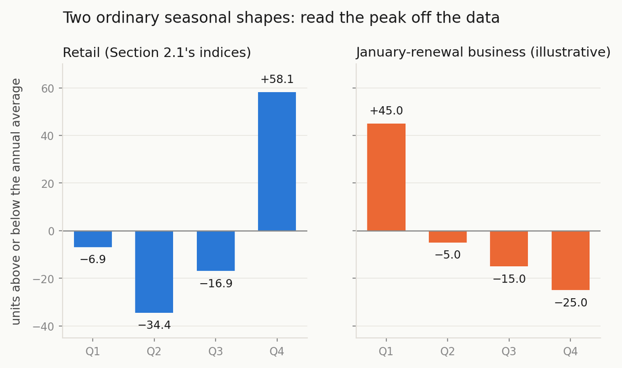

A Q4 peak is the retail pattern. Gyms, tax preparation and January renewals peak in **Q1**. Both are ordinary; the fitted component shows which one a series has.

## Seasonality: Fourier Series

Background: why it works, not on quizzes

$$s(t) = \sum_{n=1}^{N} \left[ a_n \cos\!\left(\frac{2\pi n t}{P}\right) + b_n \sin\!\left(\frac{2\pi n t}{P}\right) \right]$$

$P$ = seasonal period (365.25 for yearly, 7 for weekly)  
$N$ = Fourier order: the number of sine–cosine pairs (controls smoothness)

**Tip**

Higher order → more flexible seasonality → risk of overfitting.  
Default in Prophet: $N=10$ for yearly (20 terms), $N=3$ for weekly.

## Fourier Order on One Series

Background: why it works, not on quizzes

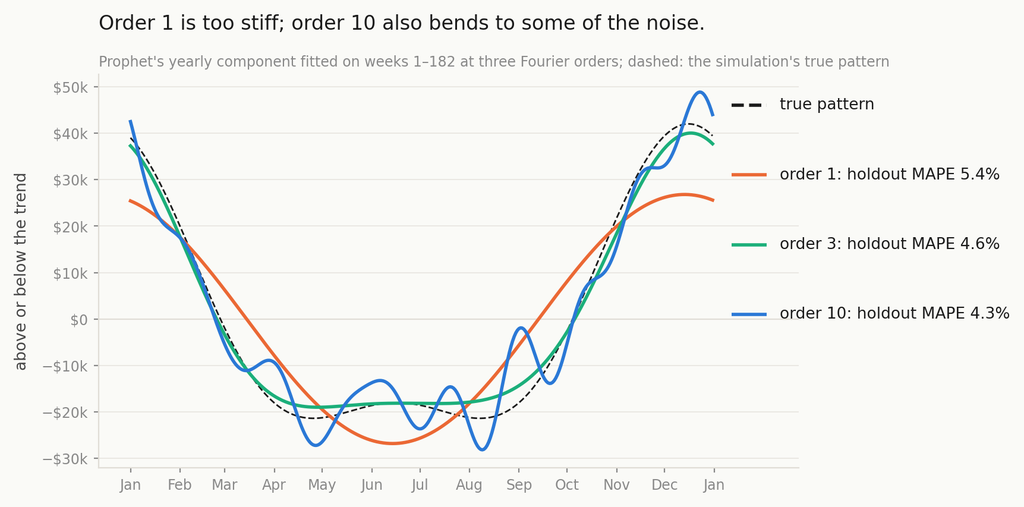

Order 10 bends to some of the noise and still has the lowest holdout MAPE here; on a shorter or noisier series it may not. Notes: Section 1.3 Deep Dive, Common Misconception 2.

## Trend Changepoints

Prophet places a **fixed** number of potential changepoints at regular intervals — `n_changepoints`, default **25**, over the first 80% of the training data (`changepoint_range=0.8`). It does **not** search for them. A sparse (Laplace) prior then shrinks each candidate’s slope adjustment toward **zero**; the ones the data pay for survive, the rest switch off.

**`changepoint_prior_scale`**

High value → model is flexible, captures many changes  
Low value → model is smooth, resists noise

Default: 0.05

**Manual changepoints:**

```python
model = Prophet(
  changepoints=['2023-08-01'],
  changepoint_prior_scale=0.3
)
```

Use when the **growth rate** changed at a known date. `changepoints=` **replaces** the 25 candidates with your list.

A permanent **level** drop (a competitor takes 15%) is not a slope change: add a 0/1 step column with `m.add_regressor()`.

## Which Candidates the Data Kept

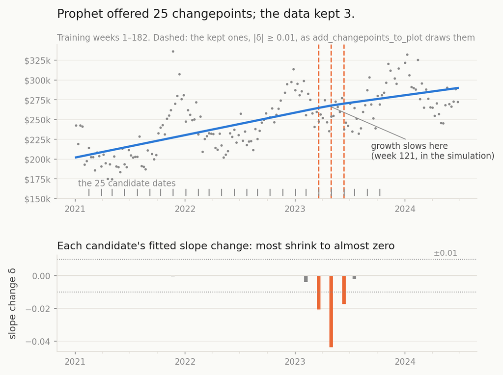

Growth slows at week 121. No candidate falls on that week; the fit keeps the three nearest (weeks 116, 122, 128). `add_changepoints_to_plot` draws the kept ones. Notes: Section 1.4B.

## The Promotional Campaign Trap

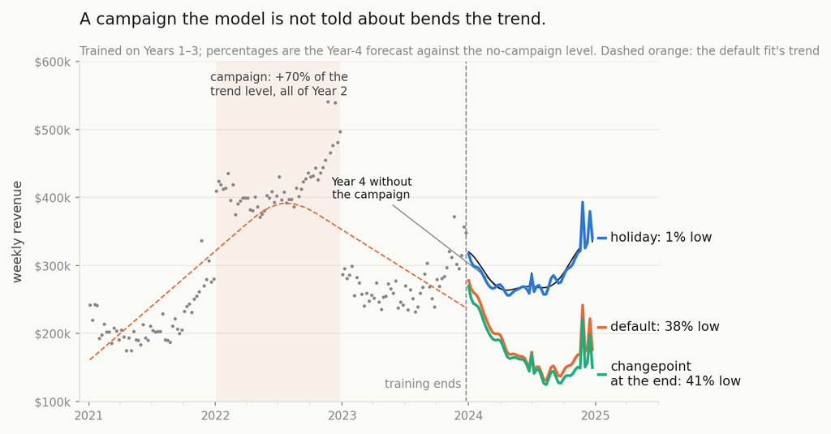

A changepoint changes slope, not level. The fix for a past campaign is a **holiday spanning its dates**. Notes: Section 1.4B.

## Worked Example: Seasonal Multipliers

You need this

Base trend: 100,000 units/week, growing +2%/week.

**After 4 weeks:**

$$100{,}000 \times 1.02^4 = 100{,}000 \times 1.0824 = \mathbf{108{,}243 \text{ units}}$$

**Q4 seasonal effect (+35%) — quoted off the base, not off the trended value:**

$$100{,}000 \times 1.35 = \mathbf{135{,}000 \text{ units}}$$

**Black Friday on top of Q4 (+45%) — quoted off the Q4 level:**

$$135{,}000 \times 1.45 = \mathbf{195{,}750 \text{ units}}$$

**Warning**

**Read which base each percentage names.** “+35%” here is a lift on the annual baseline (100,000); “+45% on top of Q4” takes the Q4 level (135,000) as *its* base, so the two multipliers chain. They are not both lifts on the same number, and they are not added.

## Measuring Forecast Accuracy: MAPE

You need this

$$\text{MAPE} = \frac{1}{n}\sum_{t=1}^{n} \frac{|y_t - \hat{y}_t|}{|y_t|} \times 100\%$$

**MAPE interpretation:**

- < 10%: excellent (tight forecasting needs)
- 10–20%: good (typical operational planning)
- 20–30%: acceptable (rough guidance only)
- above 30%: reconsider the model

**No universal threshold:**

18% MAPE for 3-month inventory planning → acceptable  
18% MAPE for 24-hour JIT production → dangerous

Context determines adequacy, not the number alone.

A higher MAPE can be the better choice when the lower one is in-sample, biased, or wrong in the weeks that matter (Notes 1.4C).

**Rough 95% range from a holdout MAPE:** level × (1 ± 2 × MAPE). $200k at 10% → $160k to $240k. Back-of-envelope only (closer to 90% coverage); use Prophet’s own interval when you have the model.

## Forecast Uncertainty and Interval Width

Prophet’s default interval has two parts:

1. **Noise**: the week-to-week scatter the fit measured in the history. Same width at every horizon.
2. **Trend uncertainty**: simulated future trend changes, as often and as large as those in the history. Grows with the horizon.

Not included by default: uncertainty in the seasonal shape (needs `mcmc_samples > 0`).

**Tip**

So intervals widen with the horizon, but on a steady series they can stay **almost constant** for months, and that is not a defect. The real warning: an interval much narrower than the errors you see on held-out data. Check how often holdout actuals fall inside it.

## Checking the Interval on a Holdout

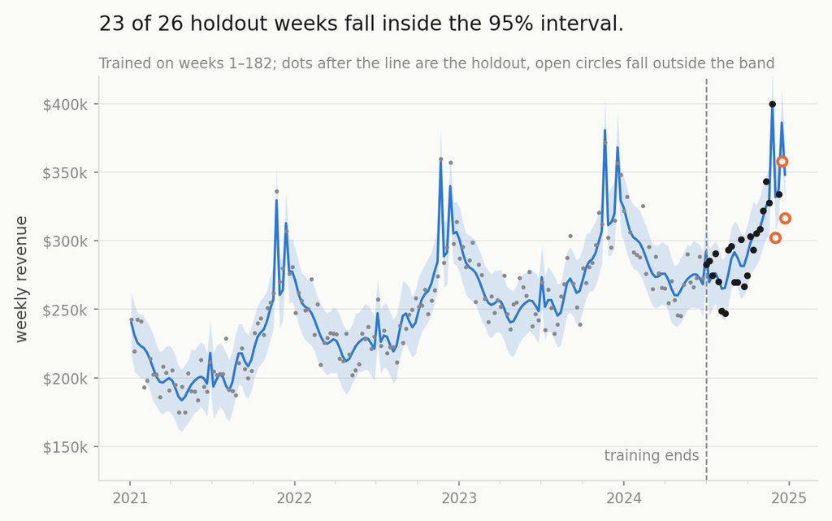

23 of 26 holdout weeks inside (88%) on a 95% interval; the band stays $42k to $50k wide, because the noise part dominates. Notes: Section 1.4A.

## Practice: work in pairs (1 of 2)

Answer each one, then mark **Sure** or **Unsure** as you would on the quiz.

**1. True or false?** A Prophet forecast’s 95% interval is about the same width at week 1 and week 26. That shows the model is misspecified.

**2.** Running out of stock costs about twice as much as overstock. Where should you plan inventory?

A. At the point forecast (yhat) B. A little above yhat C. At the upper end of the 95% interval D. At the lower end of the 95% interval

**3.** Weekly revenue level $300k, holdout MAPE 10%. What approximate 95% range does the course’s rough MAPE rule give?

A. $270k to $330k B. $290k to $310k C. $240k to $360k D. $300k to $360k

Answers in the lecture notes, under “Slide Practice Answers” (numbered to match these slides).

## Practice: work in pairs (2 of 2)

**4. True or false?** You fit `Prophet(changepoints=['2023-08-01'])`. The model still has its 25 default candidate changepoints, plus this one.

**5.** Your data has one row per week, dated on Mondays. You add US holidays with Prophet’s default settings. Which is true?

A. Every holiday gets an effect estimated  
B. Prophet moves each holiday to the nearest row  
C. Weekly data cannot use holidays at all  
D. Only holidays whose date matches a row get an effect; Thanksgiving (a Thursday) gets none

**6. True or false?** `cross_validation()` refits the model at several cutoff dates and scores each forecast by how far ahead it was.

Answers in the lecture notes, under “Slide Practice Answers” (numbered to match these slides).

## Checkpoint

1. Trend = +2.5%/week, base = 80,000 units. Forecast after 3 weeks.
2. Baseline weekly revenue = $1,200k. Q4 seasonal = +42%. Black Friday adds another +38% on top of Q4. Estimate Black Friday week revenue.
3. MAPE = 22%. Manager says “useless.” What’s your response, and what additional context do you need?
4. The model missed a competitor launch in month 6 that caused a permanent 15% demand drop. What should you do to the model?
5. The week-20 prediction interval is 4× wider than the week-1 interval. Is this a model defect?

Answers in the lecture notes, under “Slide Checkpoint Answers” (numbered to match this slide).

## On your own data: forecasting for real

**Data:** two columns, `ds` (date) and `y`, one row per week or day, and at least two full years of history.

**Tool:** `prophet`: `fit`, `predict`, then `cross_validation` + `performance_metrics` for accuracy by horizon.

**Prompt (excerpt):**

```
Fit Prophet with interval_width=<level the decision needs>. Add a changepoint at
each known event: <date: event>. Run cross_validation with horizon = <H>, several
cutoffs. Report MAPE and interval coverage by horizon, next to a seasonal-naive baseline.
```

**Before you trust it:** does it beat “same week last year”? · is coverage near the level you asked for? · weekly data: did the holidays match any rows?

**Don’t copy from HW10:** the 182/26 split, `interval_width=0.95`, “every US holiday”. Those are pinned for grading (keep the holiday window).

Full card (data, tools, the complete prompt, all checks): [Agentic Prompts → L10](https://nu-mktg.github.io/marketing-analytics/md-viewer.html?file=student/agentic_prompts_14_models.md). Not quiz material.